# Statistical Trend Analysis of Great Lakes Ice Cover Changes (1973 to 2025)

Rongrong Qian & Carter Vonderahe

November 21, 2025

# 1 Introduction

Ice cover on the Great Lakes significantly influences regional societal benefits, including hydropower generation, commercial shipping, and the fishing industry. The extent and duration of this ice cover fluctuate annually, and long term reductions linked to global warming are a key concern for scientists at the NOAA Great Lakes Environmental Research Laboratory (GLERL). Monitoring and analyzing lake ice is essential as it impacts regional climate patterns, lake water levels, water temperature structures, and vital ecological processes such as spring plankton blooms.

The goal of this report is to provide a comprehensive inferential statistical analysis examining systemic changes and trends in the annual ice cover on the Great Lakes over the past 50 years. This analysis utilizes daily percent ice cover data, derived from USNIC and CIS records, to identify and quantify potential long term shifts in this critical environmental indicator.

# 2 Methods

## 2.1 Data

### 2.1.1 Data Description

This analysis utilizes the Great Lakes daily ice cover dataset provided by the NOAA Great Lakes Environmental Research Laboratory (GLERL). The dataset comprises daily observations spanning the ice seasons (November 10 to June 5) from 1973 to 2025. The data entries represent the percentage of total ice cover for the Great Lakes, calculated from gridded ASCII files originally sourced from the U.S. National Ice Center (USNIC) and the Canadian Ice Service (CIS). In the data matrix, columns correspond to individual years, and rows correspond to the day of the year.

### 2.1.2 Data Preparation

The raw dataset contained missing values (NAs) exhibiting distinct patterns, which were addressed as follows:

**1. Leap year adjustment:**

To ensure consistent matrix dimensions across all years (uniform 365-day series), the handling of February 29 needs to be standardized. In leap years where February 29 contained valid data, the value for February 28 was recalculated as the mean of the observations from February 28 and February 29. The row corresponding to February 29 was then removed from the dataset. In non-leap years, the “NA” placeholder for February 29 was simply removed. February 29 was the only instance of missing values existing in the middle of a cold season (see Appendix A).

**2. Leading and Trailing Missing Values:**

A significant portion of missing data was concentrated at the beginning (starting November 10) and the end (approaching June 5) of the ice seasons. These missing entries likely represent “latent zeros,” indicating periods where ice cover was negligible due to warmer seasonal temperatures. Additionally, missing values in the earlier years of the dataset may be attributed to limitations in historical remote sensing capabilities or monitoring protocols, where recording only commenced once significant ice formation was visually confirmed. So, these missing values were imputed using a conditional strategy to distinguish between true absence of ice and unrecorded data. This method utilized a defined threshold, $\tau_0$.

- True Zeros: If the adjacent observed value (the first valid data point for leading gaps or the last valid point for trailing gaps) was less than or equal to $\tau_0$, the entire run of missing values was treated as “true zeros” (0% ice cover).
- Linear Extrapolation: If the adjacent observed value exceeded $\tau_0$, linear extrapolation were applied using the contiguous block of observed data immediately next to the gap.
  - Leading gaps: A linear model was fitted to the first contiguous block of data, and values were back-projected into the gap.
  - Trailing gaps: A linear model was fitted to the last contiguous block, and values were projected forward.
- Constraints: The extrapolation followed a specific stopping rule: moving outward from the observed data, as soon as a predicted value dropped below 0, that day and all remaining outer days in the gap were set to 0. Finally, all predicted values were clamped to a range of [0, 100] to prevent unrealistic values.

Exploratory analysis revealed a distinct shift in data quality around 1993, so the imputation strategy was applied only to years prior to 1993, with the exception of February 29, which was combined with February 28 as described above. Any remaining missing values in these later years were set to 0, assuming that monitoring practices improved.

## 2.2 Assumptions

### 2.2.1 Missing Data Thresholding

Missing values at the beginning and end of the ice season are treated as “latent zeros” or imputed based on adjacent data trends. For this analysis, the threshold $\tau_0$ is assumed to be 5% ice cover$^{[13]}$.

### 2.2.2 Assumptions for Trend Analysis

Although the Theil-Sen estimator is nonparametric and does not require the strict normality assumptions of ordinary least squares regression, valid inference relies on the following assumptions:

**1. Monotonic Trend Structure**

The test is designed to detect monotonic trends, meaning the variable consistently increases or decreases over time. It is assumed that the underlying trend does not exhibit complex oscillations or multiple regime shifts.

**2. Assessment of Serial Dependence**

The randomization test for trend analysis (discussed in detail in Section 2.3.2) operates under the null hypothesis of exchangeability. This assumption states that if no temporal trend exists, all permutations of the data’s time order are equally plausible. However, because this series arises from a natural system governed by large scale climatic processes, this assumption may be compromised by serial dependence (autocorrelation). To evaluate this potential violation, the Autocorrelation Function (ACF) of the annual time series is examined. If the ACF reveals weak or insignificant autocorrelation, the exchangeability assumption is considered reasonable, validating the use of a simple random permutation.

**3. Stability of Measurement**

Data collection methods and measurement accuracy are assumed to remain consistent throughout the study period. This ensures that detected trends reflect actual environmental changes rather than artifacts of the measurement process.

## 2.3 Statistical Methodology

### 2.3.1 Annual Ice Cover Metric

The primary response variable for this analysis is the sum of daily ice cover percentages over each ice season (November 10 to June 5) for each year. This metric captures the overall extent and duration of ice cover, providing a comprehensive measure of seasonal ice dynamics. The estimated cumulative ice cover index Area Under the Curve (AUC) denoted as $AUC_y$ is calculated as the sum of daily percentages:

$$AUC_y = \sum_{t=1}^{n_y} I_{y,t}$$

where $I_{y,t}$ represents the ice cover percentage on day $t$ of year $y$.

### 2.3.2 Trend Analysis and Inference

To quantify long-term changes in annual ice cover, the response $(AUC_y)$ is analyzed as a time series indexed by year $y$. In this report, non-parametric methods are employed for both estimation and inference.

**1. Trend Estimation**

The magnitude of the linear trend is estimated using the Theil-Sen slope estimator. This method computes the slopes for all possible pairs of years $i$ and $j$ where $i$ is less than $j$. The slope between years $i$ and $j$ is

$$s_{ij} = \frac{Y_j - Y_i}{t_j -
t_i},$$

where $Y_i$ and $Y_j$ are the annual ice cover metrics for years $i$ and $j$, respectively, and $t_i$ and $t_j$ are the corresponding years. The final slope estimate, denoted as $\hat{\beta}_1$, is defined as the median of these slopes calculated between pairs. This estimator is highly resistant to outliers, making it well suited for hydroclimatic time series. To visualize the trend, a reference line is constructed using $\hat{\beta}_1$ and an intercept $\hat{\beta}_0$, chosen such that the line passes through the median of the observed values.

**2. Statistical Inference via Randomization Test**

The statistical significance of the observed trend is assessed using a randomization test built around the Theil–Sen slope:

- The observed test statistic is the estimated slope $\hat{\beta}_1$ from the actual ordering of years.
- Under the null hypothesis, the slope of the trend is 0. Therefore, under the null, a given recorded AUC value in the data is equally likely to occur in any year. So, to perform the randomization test, recorded AUC values are randomly permuted to years, and the Theil–Sen slope is recalculated based on this permutation. This process is done 10,000 times to form a null distribution of slopes.
- The two-sided p-value is obtained as the proportion of permuted slopes whose absolute value is at least as large as the absolute value of the observed slope. A low p-value (< 0.05) indicates that the observed trend is considered statistically significant.

**3. Confidence Interval for the Theil–Sen Slope**

A permutation-based confidence interval was constructed by approximating the distribution of the estimation error using the permuted slopes computed under the null hypothesis ($\beta_1 = 0$). Since the randomization scheme dissociates years from their AUC values, the resulting distribution of slopes is centered at zero. By inverting this null distribution, the 95% confidence interval is formed. Let $q_{0.025}$ and $q_{0.975}$ denote the 2.5th and 97.5th percentiles of these null permuted slopes, respectively. The interval for the true parameter $\beta_1$ is given by:
$$[\hat{\beta}_1 - q_{0.975}, \quad
\hat{\beta}_1 - q_{0.025}]$$

## 2.4 Software

All statistical analyses and data visualizations were performed using the `R (version 4.5.1)` within the `RStudio` integrated development environment (version 2025.09.2+418). Data manipulation and cleaning were conducted using the `tidyverse` ecosystem, specifically `dplyr` and `tidyr` for structural reshaping, `readr` for data ingestion, `stringr` for text processing, and `lubridate` for date-time management.

Visualizations were generated using `ggplot2` to ensure consistent aesthetic standards. Time series forecasting and autocorrelation diagnostics were implemented using the `forecast` package. Finally, this report was dynamically generated using `knitr` and `kableExtra` to ensure reproducibility and streamlined table formatting.

# 3 Results

## 3.1 Analysis of Missing Values

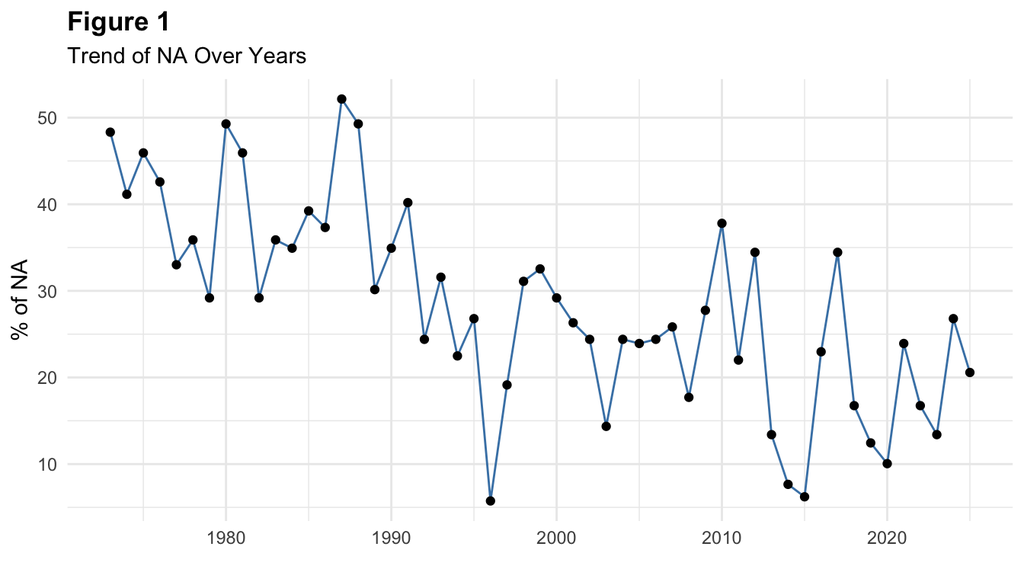

Figure 1 illustrates the temporal trend in missing data across the study period (1973–2025). The percentage of missing values for each year was calculated as the ratio of missing days to the total number of days in the ice season ($NA\_percentage = \frac{NA\_count}{total\_days} \times 100$). A clear decreasing trend in missing data is observed over time. In the earlier decades (1970s and 1980s), the proportion of missing values fluctuated significantly, often exceeding 40% to 50%. Conversely, in the most recent decades, the proportion has generally stabilized at lower levels, frequently falling below 20%. This pattern likely reflects improvements in data collection technologies, such as satellite remote sensing, and more consistent monitoring protocols in recent years. The presence of these NAs underscores the importance of the imputation strategies outlined in Section 2.1.2.

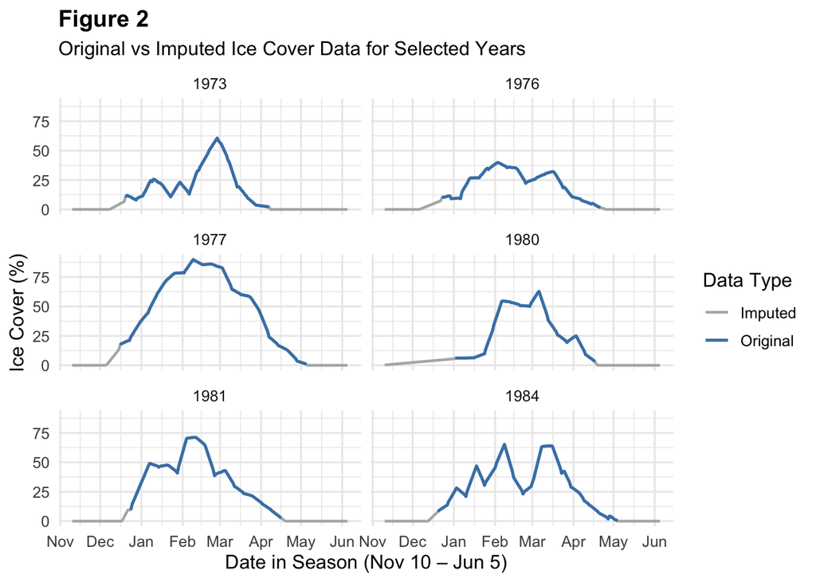

## 3.2 Assessing Duration and Intensity

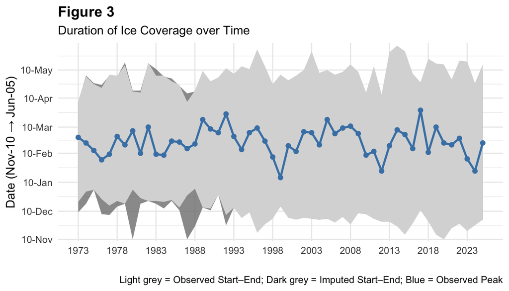

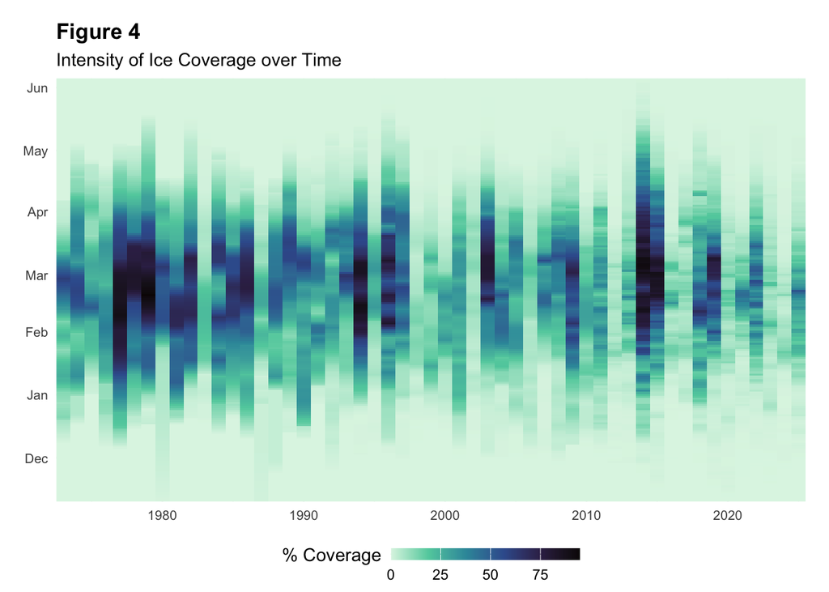

Figure 4 visualizes daily ice intensity after imputation of missing values, where the color gradient transitions from light teal (low cover) to dark purple (high cover). A clear temporal shift is evident: early decades display broad dark bands, whereas recent years feature lighter tones, signaling a reduction in ice coverage. Despite this long-term decline, the seasonal peak consistently remains centered in February and March. Again, the effect of the El Niño events manifests in shorter seasons and unusually low ice cover around the years 1998, 2016, and 2023.